# 3 Data Visualization

## Exercícios 3.7.1

O geom padrão de stat_summary é pointrange, então poderiamos reescrever.

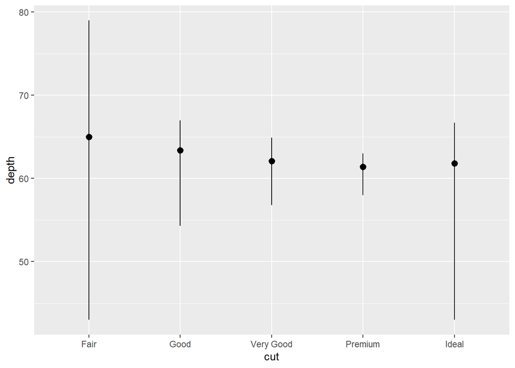

```r
ggplot(diamonds,aes(cut,depth)) + geom_pointrange(stat='summary',fun= median,fun.min=min,fun.max=max)
```

geom_col produz gráficos que contem valores referentes aos observado nos dados, sua stat padrão é identity.

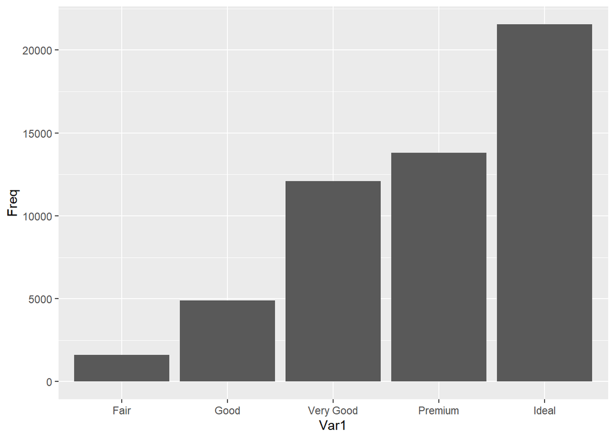

```r
ggplot(table(diamonds$cut) %>% as.data.frame) + geom_col(aes(x=Var1,y=Freq))
```

As variáveis computadas por stat_smooth são y (valor previsto), ymin (Menor ponto do IC), ymax (Maior ponto do IC) e se (Desvio Padrão). Os parametros que controlam essas variaveis são method = Método usado para prever o Y pode ser definido mas tem dois padrões. se = Apresentar o desvio padrão. formula = Quando o método padrão não é utilizado informar a formula ex: y~x+I(x^2) e method.arg = argumentos sem ser a formula que devem ser definidos.

## Position Adjustments

Podemos colorir barras usando color ou fill. Color é apenas para a margem da barra enquanto fill é um preenchimento completo.

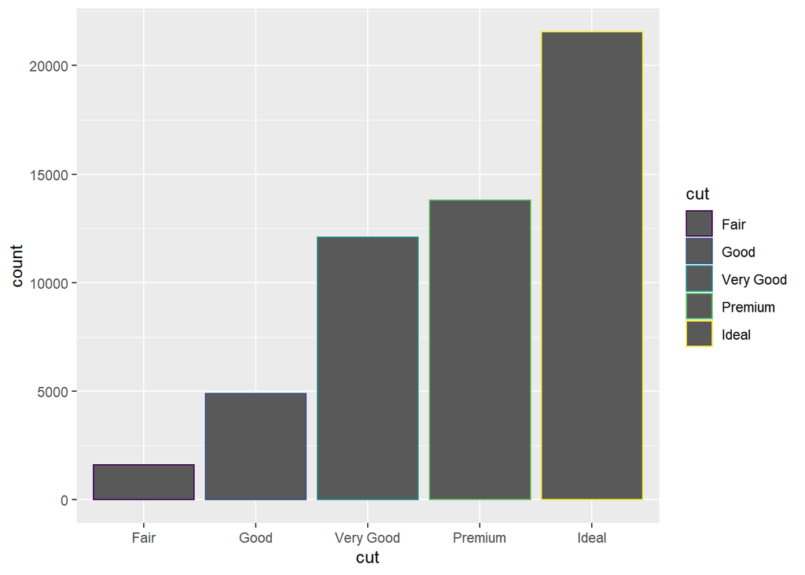

```r
ggplot(data = diamonds) +
  geom_bar(mapping = aes(x = cut, colour = cut))
```

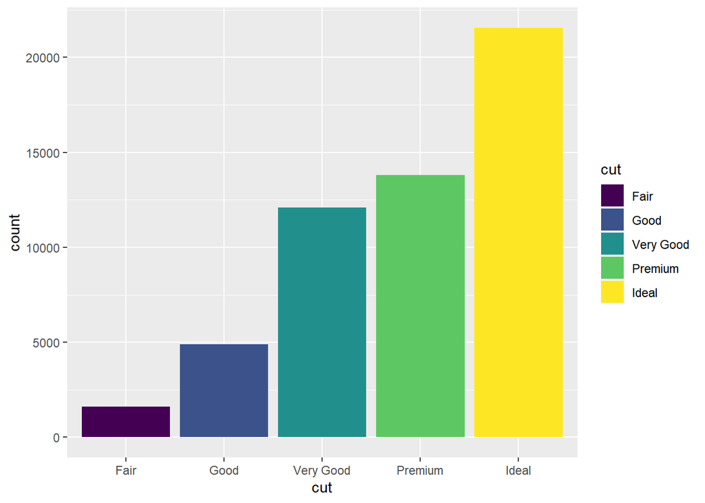

```r
ggplot(data = diamonds) +
  geom_bar(mapping = aes(x = cut, fill = cut))
```

Se fizermos o mapeamento de fill para outra variável as barras ficam empilhadas.

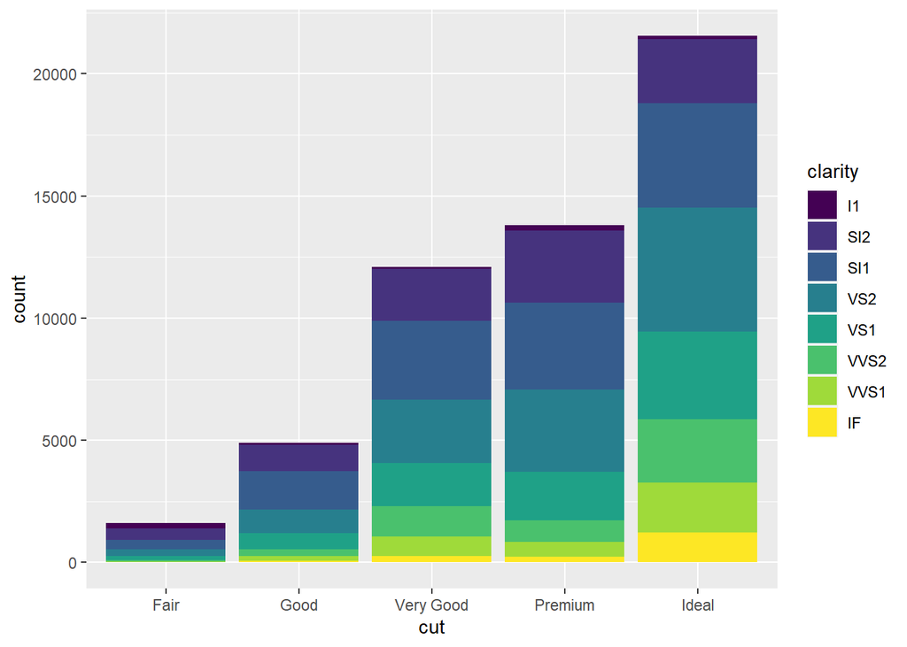

```r
ggplot(diamonds) +
  geom_bar(aes(cut,fill=clarity))
```

Esse empilhamento ocorre devido ao argumento position que tem como padrão stack. Se quisermos o valor real de cada um aparecendo na mesma coluna mas sem estar empilhado temos que deixar as barras transparentes caso usemos identity. Podemos fazer isso por meio do argumento alpha ou deixar o fill vazio apenas com os contornos.

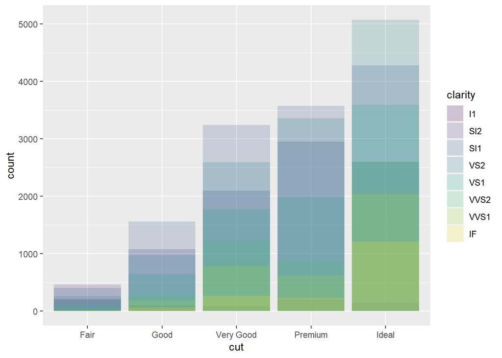

```r
ggplot(data = diamonds, mapping = aes(x = cut, fill = clarity)) +
  geom_bar(alpha = 1/5, position = "identity")
```

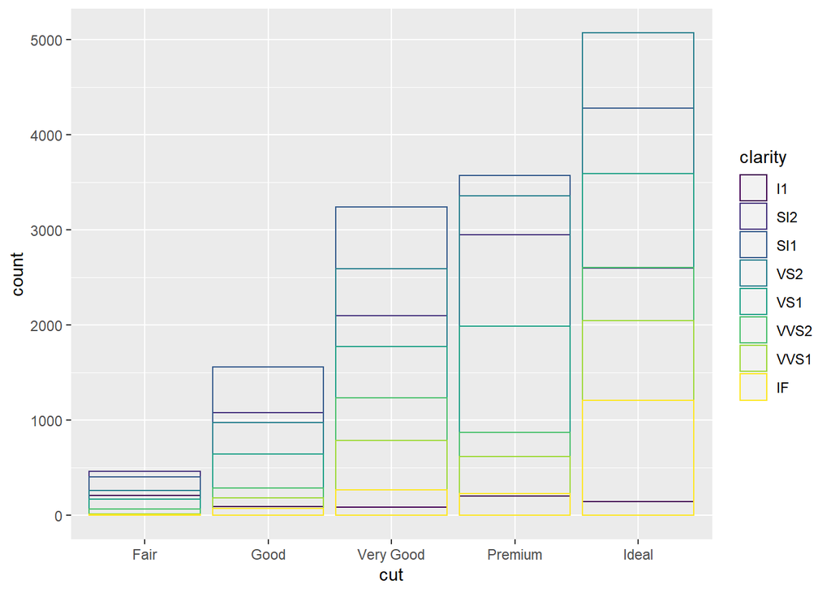

```r
ggplot(data = diamonds, mapping = aes(x = cut, colour = clarity)) +
  geom_bar(fill = NA, position = "identity")
```

Position = fill faz a mesma coisa que stack mas com barras percentuais, ou seja todas com o mesmo tamanho, facilitando a comparação entre os grupos.

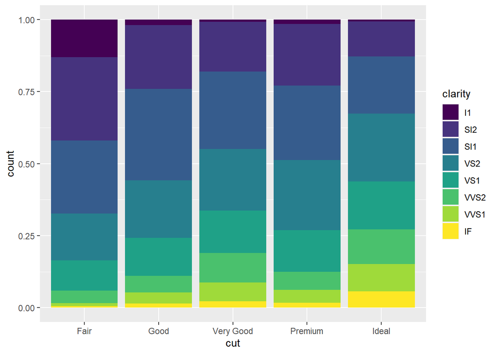

```r
ggplot(data = diamonds) +
  geom_bar(mapping = aes(x = cut, fill = clarity), position = "fill")
```

Position = Dodge cria varias barras uma ao lado do outro, permitindo uma boa vizualização de cada grupo mas uma geral um pouco mais limitada.

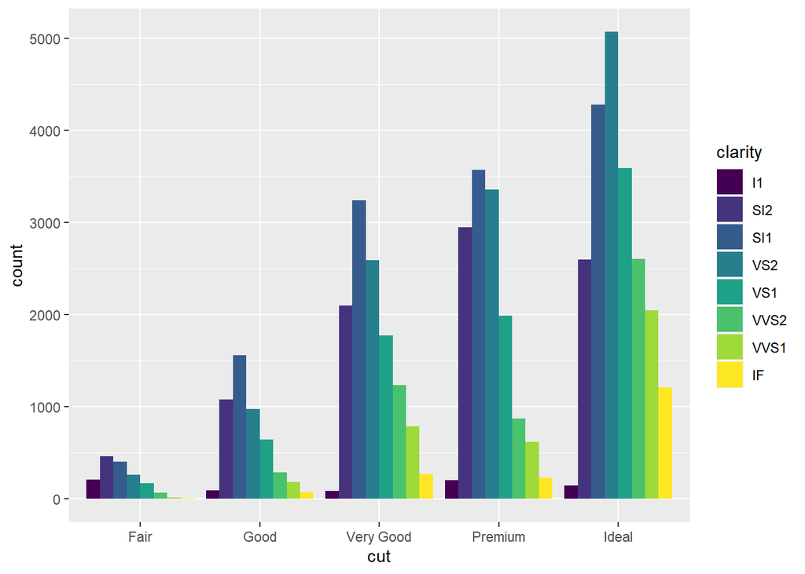

```r
ggplot(data = diamonds) +
  geom_bar(mapping = aes(x = cut, fill = clarity), position = "dodge")
```

Para gráficos de dispersão podemos ter pontos se sobrepondo, como no nosso primeiro exemplo, isso acontece ainda mais quando temos arredondamentos, como exemplo o primeiro gráfico que foi feito tinha 234 observações mas no gráfico vemos apenas 126.

```r
ggplot(mpg) + geom_point(mapping= aes(displ,hwy))
```

[output not shown]

Uma maneira de evitar que isso aconteça é colocar o argumento jitter em position, dessa maneira cada ponto recebe um leve ajuste aleatorio, por ser improvavel que 2 pontos recebam o mesmo ajuste isso faz com que a vizualização se torne mais clara para pontos proximos.

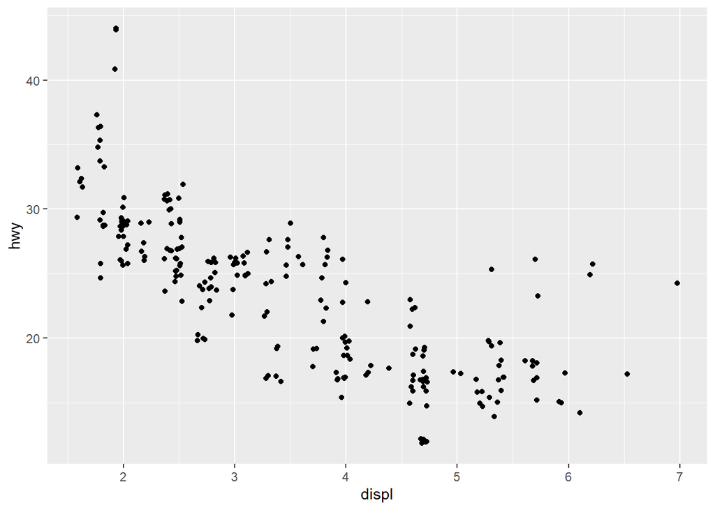

```r
ggplot(mpg) + geom_point(mapping= aes(displ,hwy),position='jitter')
```

Existe um atalho para esse argumento, a função geom_jitter faz esse barulho automaticante.

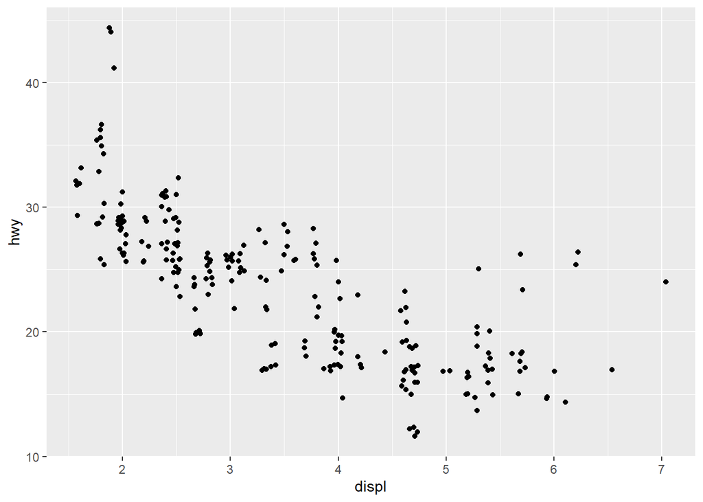

```r
ggplot(mpg) + geom_jitter(aes(displ,hwy))
```